# Project Business Statistics: E-news Express

**Marks: 60**

## Define Problem Statement and Objectives

# Problem Statement

## Business Context

E-news Express is an online news source that executives want to grow through gaining new subscribers. The company plans to analyze actions taken by each visitor to better understand user interests; one of the main goals is to determine what drives better engagement. Executives at E-news Express believe there has been a drop in new monthly subscribers due to the poor quality of the existing webpage. Specifically, the executives are concerned about the outline and recommended content needed to keep customers engaged long enough for them to subscribe.

## Objective

The E-news Express design team has created a new landing page. This new landing page has a new outline and more relevant content relative to the current page. To test how effective the new landing page is at gaining new subscribers, the Data Science team randomly selected 100 users that were divided equally into two groups. The first (control) group observed the existing landing page while the second (treatment) group observed the new landing page. Data on the interaction of the users with their respective landing pages was collected. As a data scientist, you have been asked to explore the data and perform statistical analysis - using a 5% level of significance - to determine how effective the new landing page is at gaining new subscribers. To do this analysis, the following questions must be addressed:

- Do the users spend more time on the new landing page than on the old landing page?
- Is the conversion rate for the new page greater than the conversion rate for the old page?
- How does the user's preferred language relate to converted status?
- Is the time spent on the new page the same for users with different preferred languages?

## Data Dictionary

The data contains information regarding the interaction of users in both groups with the two versions of the landing page.

- user_id - Unique user ID of the person visiting the website
- group - Whether the user belongs to the first group (control) or the second group (treatment)
- landing_page - Whether the landing page is new or old
- time_spent_on_the_page - Time (in minutes) spent by the user on the landing page
- converted - Whether the user gets converted to a subscriber of the news portal or not
- language_preferred - Language chosen by the user to view the landing page

## Import all the necessary libraries

```python
# import the important libraries / packages
import pandas as pd
import numpy as np
import matplotlib.pyplot as plt
import seaborn as sns

#%matplotlib inline

import scipy.stats as stats
```

## Reading the Data into a DataFrame

```python
# set to reference Google Drive
from google.colab import drive
drive.mount('/content/drive')
```

```python
# read the data
df = pd.read_csv('/content/drive/MyDrive/Python Course/abtest.csv')
```

## Explore the dataset and extract insights using Exploratory Data Analysis

- Data Overview
  - Viewing the first and last few rows of the dataset
  - Checking the shape of the dataset
  - Getting the statistical summary for the variables
- Check for missing values
- Check for duplicates

```python
# return the first 5 rows of the dataframe
df.head()
```

|  | user_id | group | landing_page | time_spent_on_the_page | converted | language_preferred |
| --- | --- | --- | --- | --- | --- | --- |
| 0 | 546592 | control | old | 3.48 | no | Spanish |
| 1 | 546468 | treatment | new | 7.13 | yes | English |
| 2 | 546462 | treatment | new | 4.40 | no | Spanish |
| 3 | 546567 | control | old | 3.02 | no | French |
| 4 | 546459 | treatment | new | 4.75 | yes | Spanish |

```python
# return the last 5 rows of the data
df.tail()
```

|  | user_id | group | landing_page | time_spent_on_the_page | converted | language_preferred |
| --- | --- | --- | --- | --- | --- | --- |
| 95 | 546446 | treatment | new | 5.15 | no | Spanish |
| 96 | 546544 | control | old | 6.52 | yes | English |
| 97 | 546472 | treatment | new | 7.07 | yes | Spanish |
| 98 | 546481 | treatment | new | 6.20 | yes | Spanish |
| 99 | 546483 | treatment | new | 5.86 | yes | English |

```python
#Find the number of rows and columns in the dataframe
df.shape
```

```
(100, 6)
```

#### Observations

There are 100 rows and 6 columns in df created from abtest.csv.

```python
# use info() to print a concise summary
df.info()
```

```
<class 'pandas.core.frame.DataFrame'>
RangeIndex: 100 entries, 0 to 99
Data columns (total 6 columns):
 #   Column                  Non-Null Count  Dtype
---  ------                  --------------  -----
 0   user_id                 100 non-null    int64
 1   group                   100 non-null    object
 2   landing_page            100 non-null    object
 3   time_spent_on_the_page  100 non-null    float64
 4   converted               100 non-null    object
 5   language_preferred      100 non-null    object
dtypes: float64(1), int64(1), object(4)
memory usage: 4.8+ KB
```

#### Observations

- group, landing_page, converted, and language_preferred are of type string
- user_id is of type integer
- time_spent_on_the_page is of type float
- none of the variables contain null values

```python
# basic statistics on all variables
df.describe(include = "all")
```

|  | user_id | group | landing_page | time_spent_on_the_page | converted | language_preferred |
| --- | --- | --- | --- | --- | --- | --- |
| count | 100.000000 | 100 | 100 | 100.000000 | 100 | 100 |
| unique | NaN | 2 | 2 | NaN | 2 | 3 |
| top | NaN | control | old | NaN | yes | Spanish |
| freq | NaN | 50 | 50 | NaN | 54 | 34 |
| mean | 546517.000000 | NaN | NaN | 5.377800 | NaN | NaN |
| std | 52.295779 | NaN | NaN | 2.378166 | NaN | NaN |
| min | 546443.000000 | NaN | NaN | 0.190000 | NaN | NaN |
| 25% | 546467.750000 | NaN | NaN | 3.880000 | NaN | NaN |
| 50% | 546492.500000 | NaN | NaN | 5.415000 | NaN | NaN |
| 75% | 546567.250000 | NaN | NaN | 7.022500 | NaN | NaN |
| max | 546592.000000 | NaN | NaN | 10.710000 | NaN | NaN |

#### Observations

- Only time_spent_on_page is an actual numerical value
  - For time_spent_on_the_page:
    - Mean is 5.38 minutes
    - Median is 5.42 minutes
    - Standard Deviation is 2.38 minutes
    - Minimum and Maximum are 0.19 minutes and 10.71 minutes, respectively
- user_id is not an actual numerical value from which any meaning can be derived
- There are two unique values for the categorical variable group
- There are two unique values for the categorical variable landing_page
- There are two unique values for the categorical variable converted
- There are three unique values for the categorical variable language_preferred

```python
# find unique values for categorical values
df['group'].value_counts()
```

```
control      50
treatment    50
Name: group, dtype: int64
```

- 50 users are in the control group and 50 users are in the treatment group

```python
# find unique values for categorical values
df['landing_page'].value_counts()
```

```
old    50
new    50
Name: landing_page, dtype: int64
```

- 50 observations of landing_page are new and 50 observations of landing_page are old

```python
# find unique values for categorical values
df['converted'].value_counts()
```

```
yes    54
no     46
Name: converted, dtype: int64
```

- Overall, 54 users are converted to a subscriber, while 46 did not

```python
# find unique values for categorical values
df['language_preferred'].value_counts()
```

```
Spanish    34
French     34
English    32
Name: language_preferred, dtype: int64
```

- language_preferred is nearly evenly split
  - 34 users prefer Spanish
  - 34 users prefer French
  - 32 users prefer English

```python
# check for duplicate observations
df.duplicated().value_counts()
```

```
False    100
dtype: int64
```

#### Observations

- None of the observations are found to be duplicates

### Univariate Analysis

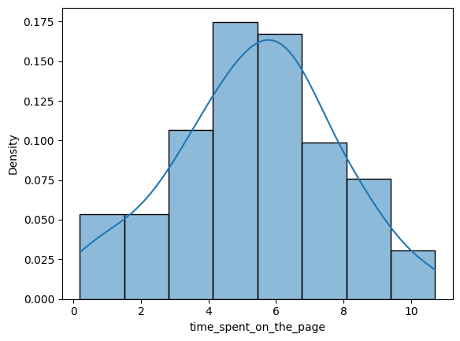

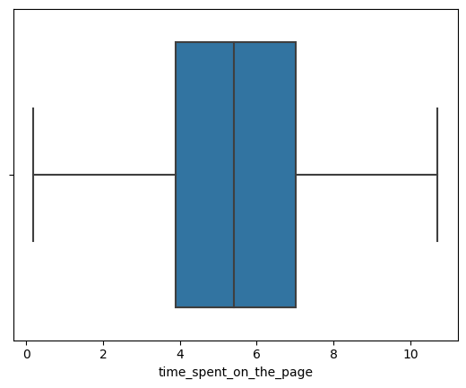

```
<function matplotlib.pyplot.show(close=None, block=None)>
```

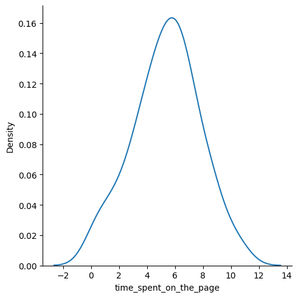

```python
# create a histogram, box plot and displot for the one true numerical variable, time_spent_on_the_page
sns.histplot(data = df, x = 'time_spent_on_the_page', stat = 'density', kde = 'true')
plt.show()
sns.boxplot(data = df, x = 'time_spent_on_the_page')
plt.show()
sns.displot(data = df, x = 'time_spent_on_the_page', kind = 'kde')
plt.show
```

#### Observations

- time_spent_on_the_page appears to be nearly perfectly normally distributed
- The range is 0.19 to 10.71 minutes
- First quartile, median, and third quartile are 3.88 minutes, 5.42 minutes, and 7.02 minutes, respectively

```
(array([0, 1]), [Text(0, 0, 'control'), Text(1, 0, 'treatment')])
```

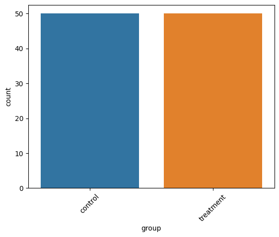

```python
# Visualize categorical variable group
sns.countplot(data=df, x = 'group')
plt.xticks(rotation=45)
```

#### Observations

- group is split evenly with 50 as control and 50 as treatment

```
(array([0, 1]), [Text(0, 0, 'old'), Text(1, 0, 'new')])
```

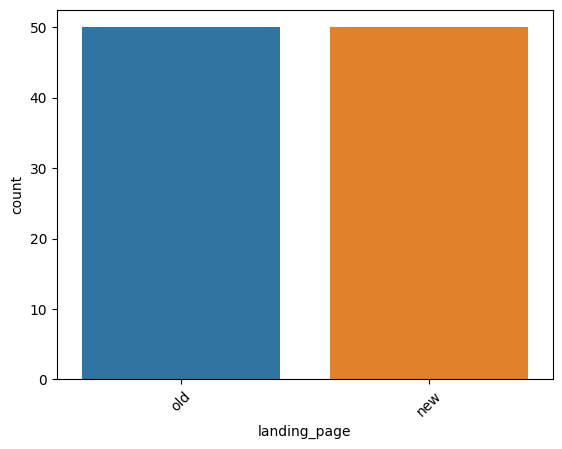

```python
# Visualize categorical variable landing_page
sns.countplot(data=df, x = 'landing_page')
plt.xticks(rotation=45)
```

#### Observations

- landing_page is split evenly with 50 as old and 50 as new

```
(array([0, 1]), [Text(0, 0, 'no'), Text(1, 0, 'yes')])
```

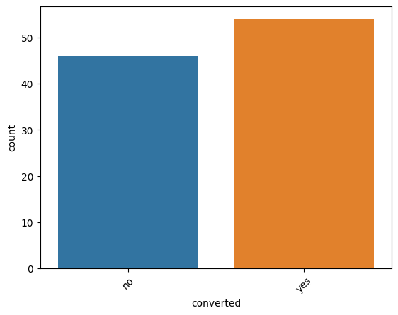

```python
# Visualize categorical variable converted
sns.countplot(data=df, x = 'converted')
plt.xticks(rotation=45)
```

#### Observations

- converted has 54 observations as yes and 46 observations as no

```
(array([0, 1, 2]),
 [Text(0, 0, 'Spanish'), Text(1, 0, 'English'), Text(2, 0, 'French')])
```

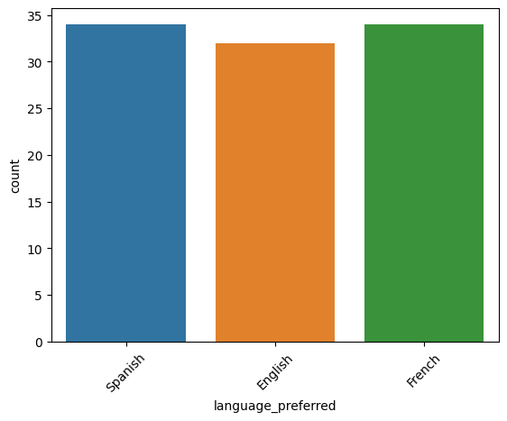

```python
# Visualize categorical variable language_preferred
sns.countplot(data=df, x = 'language_preferred')
plt.xticks(rotation=45)
```

### Observations

- language_preferred has 34 observations as Spanish, 32 observations as English, and 34 observations as French

### Bivariate Analysis

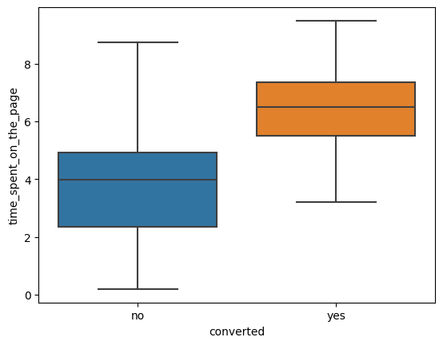

```python
# Create a visualization of time_spent_on_the_page by converted
sns.boxplot(data=df,x='converted', y='time_spent_on_the_page',showfliers=False)
```

#### Conclusion

- The median time_spent_on_the_page is around 4 minutes for users that were not converted to a subscriber (i.e., converted = no)
- The median time_spent_on_the_page is around 6.5 minutes for users that were converted to a subscriber (i.e., converted = yes)
- 75% of users that converted (i.e., yes) have a greater time_spent_on_the_page than 75% of users that did not covert (i.e., no)

```python
# Find number converted and number not converted for both the new landing page and the old landing page
print(df[df['landing_page']=='new'].converted.value_counts())
print(df[df['landing_page']=='old'].converted.value_counts())
```

```
yes    33
no     17
Name: converted, dtype: int64
no     29
yes    21
Name: converted, dtype: int64
```

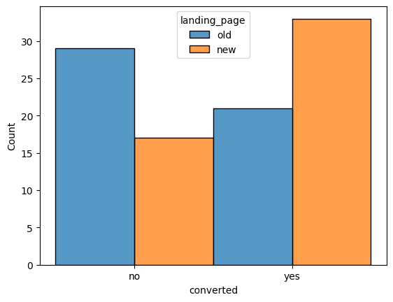

```python
# Create a visualization of converted and landing_page
sns.histplot(x="converted", hue="landing_page", data=df, stat="count", multiple = "dodge")
```

#### Observations

- The number converted to subscribers when landing_page is new is 33.
- The number not converted to subscribers when landing_page is new is 17.
- The number converted to subscribers when landing_page is old is 21.
- The number not converted to subscribers when landing_page is old is 29.

```python
# Find number converted and number not converted for the three preferred languages
print(df[df['language_preferred']=='Spanish'].converted.value_counts())
print(df[df['language_preferred']=='English'].converted.value_counts())
print(df[df['language_preferred']=='French'].converted.value_counts())
```

```
yes    18
no     16
Name: converted, dtype: int64
yes    21
no     11
Name: converted, dtype: int64
no     19
yes    15
Name: converted, dtype: int64
```

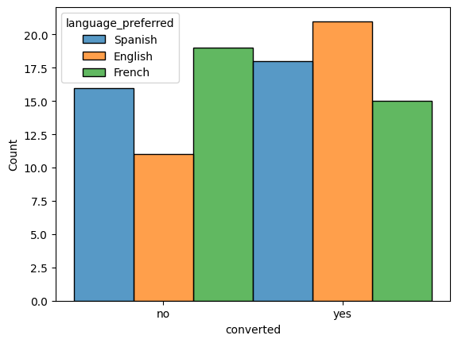

```python
# Create a visualization of converted and language_specified
sns.histplot(x="converted", hue="language_preferred", data=df, stat="count", multiple = "dodge")
```

#### Observations

- The number of users with a preferred language of English that converted is 21, while the number that did not convert is 11.
- The number of users with a preferred language of Spanish that converted is 18, while the number that did not convert is 16.
- The number of users with a preferred language of French that converted is 15, while the number that did not convert is 19.

## 1. Do the users spend more time on the new landing page than the existing landing page?

### Perform Visual Analysis

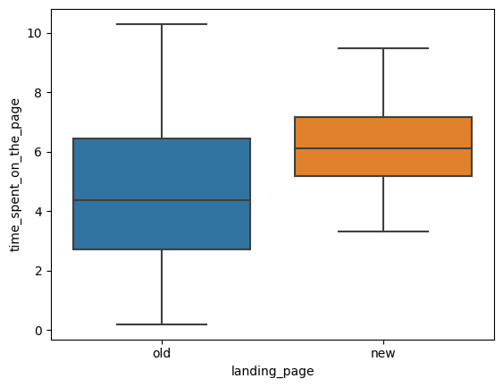

```python
# Create a visualization of time_spent_on_the_page by converted
sns.boxplot(data=df,x='landing_page', y='time_spent_on_the_page',showfliers=False)
```

### Step 1: Define the null and alternate hypotheses

Let $\mu_1$ be the mean time spent on the new landing page and $\mu_2$ be the mean time spent on the old landing page.

The null hypothesis is that the mean time spent on the new landing page is equal to the mean time spent on the old landing page.

> $H_0:\mu_1=\mu_2$

The alternative hypothesis is that the mean time spent on the new landing page is greater than the mean time spent on the old landing page.

> $H_a:\mu_1>\mu_2$

### Step 2: Select Appropriate test

```python
# find the sample means and sample standard deviations for the two samples
mean_new = df.loc[df['landing_page']=="new"].time_spent_on_the_page.mean()
mean_old = df.loc[df['landing_page']=="old"].time_spent_on_the_page.mean()
print('The mean time spent on the new landing page is ' + str(round(mean_new,2)))
print('The mean time spent on the old landing page is ' + str(round(mean_old,2)))

std_new = df.loc[df['landing_page']=="new"].time_spent_on_the_page.std()
std_old = df.loc[df['landing_page']=="old"].time_spent_on_the_page.std()
print('The standard deviation of time spent on new landing page is ' + str(round(std_new,2)))
print('The standard deviation of time spent on old landing page is ' + str(round(std_old,2)))
```

```
The mean time spent on the new landing page is 6.22
The mean time spent on the old landing page is 4.53
The standard deviation of time spent on new landing page is 1.82
The standard deviation of time spent on old landing page is 2.58
```

### Are the T-test assumptions are satisfied or not?

- Continuous data - Yes, the time_spent_on_the_page is on a continuous scale.
- Normally distributed populations - Yes, time_spent_on_the_page appears to be normally distributed.
- Independent populations - Yes, as we are taking random samples for two different landing_page types, the two samples are from two independent populations. Additionally, it is given that the sample observations are independent of each other.
- Unequal population standard deviations - Yes, as the sample standard deviations are different, the population standard deviations cannot be assumed to be equal. Population standard deviations are unknown.
- Random sampling from the population - Yes, the collected sample is a simple random sample.

We can use two sample independent t-test (unequal standard deviations) for this problem.

### Step 3: Decide the significance level

#### Significance Level

- This has been given as 5%

### Step 4: Collect and prepare data

```python
# find the sample means and sample standard deviations for the two samples
mean_new = df.loc[df['landing_page']=="new"].time_spent_on_the_page.mean()
mean_old = df.loc[df['landing_page']=="old"].time_spent_on_the_page.mean()
print('The mean time spent on the new landing page is ' + str(round(mean_new,2)))
print('The mean time spent on the old landing page is ' + str(round(mean_old,2)))

std_new = df.loc[df['landing_page']=="new"].time_spent_on_the_page.std()
std_old = df.loc[df['landing_page']=="old"].time_spent_on_the_page.std()
print('The standard deviation of time spent on new landing page is ' + str(round(std_new,2)))
print('The standard deviation of time spent on old landing page is ' + str(round(std_old,2)))
```

```
The mean time spent on the new landing page is 6.22
The mean time spent on the old landing page is 4.53
The standard deviation of time spent on new landing page is 1.82
The standard deviation of time spent on old landing page is 2.58
```

### Step 5: Calculate the p-value

```python
#create data frame where landing page is new
df_new = df[df['landing_page']=='new']
#create data frame where landing page is old
df_old = df[df['landing_page']=='old']

#import the required functions
from scipy.stats import ttest_ind

# find the p-value
test_stat, p_value = ttest_ind(df_new['time_spent_on_the_page'], df_old['time_spent_on_the_page'], equal_var = False, alternative = 'greater')
print('The p-value is ' + str(p_value))
```

```
The p-value is 0.0001392381225166549
```

### Step 6: Compare the p-value with $\alpha$

```python
alpha = 0.05
p_value = p_value

if p_value <= alpha:
  print("Reject the Null that the time spent on the new page is the same as the time spent on the old page")
else:
  print("Do Not Reject the Null that the time spent on the new page is the same as the time spent on the old page")
```

```
Reject the Null that the time spent on the new page is the same as the time spent on the old page
```

### Step 7: Draw inference

#### Observations

- The p-value is much lower than the significance level of 0.05, we therefore reject the null hypothesis that the mean time spent on the new landing page is equal to the mean time spent on the old landing page.
- Hence, we have enough evidence to support the claim that the mean time spent on the new landing page is greater than the mean time spent on the old landing page.

**A similar approach can be followed to answer the other questions.**

## 2. Is the conversion rate (the proportion of users who visit the landing page and get converted) for the new page greater than the conversion rate for the old page?

### Null and alternative hypothesis

Let $p_1,p_2$ be the conversion rates for the new landing page and the old landing page, respectively.

Test the null hypothesis

> $H_0:p_1 = p_2$

against the alternate hypothesis

> $H_a:p_1 > p_2$

```python
conversions_new = df_new.loc[df_new['converted']=="yes"].converted.count()
print("Number of conversions for the new page is " +str(conversions_new))
sample_size_new = df_new.shape[0]
print("Number of observations for the new page is " +str(sample_size_new))
conversions_old = df_old.loc[df_old['converted']=="yes"].converted.count()
print("Number of conversions for the old page is " + str(conversions_old))
sample_size_old = df_old.shape[0]
print("Number of observations for the old page is " + str(sample_size_old))
```

```
Number of conversions for the new page is 33
Number of observations for the new page is 50
Number of conversions for the old page is 21
Number of observations for the old page is 50
```

#### Are the Z-test assumptions satisfied or not?

- Binomially distributed population - Yes, users are either converted to subscribers or not.
- Random sampling from the population - Yes, we are informed that the sample is a random sample that is evenly split into two groups.
- Can the binomial distribution be approximated to a normal distribution - Yes, CLT works for binary data, but must be tested. We must check whether np and n(1-p) are greater than or equal to 10. *In this case, n is sample size and p is sample proportion.

> $np_1 = 50\cdot \frac{33}{50} =33 \geq 10\\ n(1-p_1) = 50 \cdot \frac{50-33}{50} =17 \geq 10 \\ np_2 = 50\cdot \frac{21}{50} =21 \geq 10\\ n(1-p_2) = 50 \cdot \frac{50-21}{50} =29 \geq 10 $

```python
#import the required function
from statsmodels.stats.proportion import proportions_ztest

# set the counts of conversions
conversion_count = np.array([conversions_new, conversions_old])
print(conversion_count)

# set the sample sizes
nobs = np.array([sample_size_new, sample_size_old])
print(nobs)

# find the p-value
test_stat, p_value = proportions_ztest(conversion_count, nobs)
print('The p-value is ' + str(round(p_value,5)))
```

```
[33 21]
[50 50]
The p-value is 0.01605
```

#### Observations

- Since the p-value is less than the required significance level of 0.05, we reject the null hypothesis that conversion rates are the same for the new landing page and the old landing page.
- We do have enough evidence to support the claim that the conversion rate for the new landing page is greater than the conversion rate for the old landing page.

## 3. Are the conversion and preferred language independent or related?

### Look again at sample data

```python
# create new dummy variable: converted_yes
def f_a(row):
  if row['converted'] == 'yes':
    val = 1
  else:
    val = 0
  return val

df['converted_yes'] = df.apply(f_a, axis=1)
```

```python
#create a new dummy variable: converted_no
def f_b(row):
  if row['converted'] == 'no':
    val = 1
  else:
    val = 0
  return val

df['converted_no']=df.apply(f_b, axis=1)
```

```python
df.head()
```

|  | user_id | group | landing_page | time_spent_on_the_page | converted | language_preferred | converted_yes | converted_no |
| --- | --- | --- | --- | --- | --- | --- | --- | --- |
| 0 | 546592 | control | old | 3.48 | no | Spanish | 0 | 1 |
| 1 | 546468 | treatment | new | 7.13 | yes | English | 1 | 0 |
| 2 | 546462 | treatment | new | 4.40 | no | Spanish | 0 | 1 |
| 3 | 546567 | control | old | 3.02 | no | French | 0 | 1 |
| 4 | 546459 | treatment | new | 4.75 | yes | Spanish | 1 | 0 |

```python
#create new df1 and drop unneccesary columns
df1 = df.drop(['user_id','group','landing_page','time_spent_on_the_page','converted'], axis=1)

df2 = df1.groupby(['language_preferred'])

#create new df3 with sum of 'converted_yes' by 'language_preferred'
df3 = df2.agg(sum_converted_yes = ('converted_yes', np.sum))

#create new df4 with sum of 'converted_no' by 'language_preferred'
df4 = df2.agg(sum_converted_no = ('converted_no', np.sum))

#merge df3 and df4 to create contingency table
df5 = pd.merge(df3,df4,how='left',on='language_preferred')

print(df5)
```

```
                    sum_converted_yes  sum_converted_no
language_preferred
English                            21                11
French                             15                19
Spanish                            18                16
```

### Let's write the null and alternative hypothesis

We will test the null hypothesis

> $H_0:$ Conversion is independent of preferred language.

against the alternate hypothesis

> $H_a:$ Conversion depends on preferred language.

### Test whether the assumptions are satisfied or not

- Categorical variables - Yes
- Expected value of the number of sample observations in each level of the variable is at least 5 - Yes, the number of observations in each level is greater than 5.
- Random sampling from the population - Yes, we are informed that the collected sample is a simple random sample.

We can use Chi-Square Test of Independence for this problem.

#### Determine the p-value

```python
# import the required function
from scipy.stats import chi2_contingency

# find the p-value
chi, p_value, dof, expected = chi2_contingency(df5)
print('The p-value is ' + str(round(p_value,5)))
```

```
The p-value is 0.21299
```

#### Observations

- P-value is greater than the significance level of 0.05.
- Therefore, we cannot reject the null hypothesis that conversion is independent of preferred language.

## 4. Is the time spent on the new page same for the different language users?

- The Data Science team is tasked with finding out if the time spent on the new page is the same or different for the three preferred languages: Spanish, French, and English.
- Preferred language is a categorical variable and time spent on the new page is a continuous variable.

```python
# Consider only observations where landing page is new
df_new = df[df['landing_page']=='new']
df_new['language_preferred'].value_counts()
```

```
Spanish    17
French     17
English    16
Name: language_preferred, dtype: int64
```

### Null and Alternative Hypothesis

Let $\mu_1, \mu_2, \mu_3$ be the means of the time spent on the new page for preferred language equal to Spanish, French, and English, respectively.

We will test the null hypothesis:

> $H_0: \mu_1 = \mu_2 = \mu_3$

against the alternative hypothesis:

> $H_a: $ At least one preferred language has a different time spent on the new page from the rest.

```
language_preferred
English    6.663750
French     6.196471
Spanish    5.835294
Name: time_spent_on_the_page, dtype: float64
```

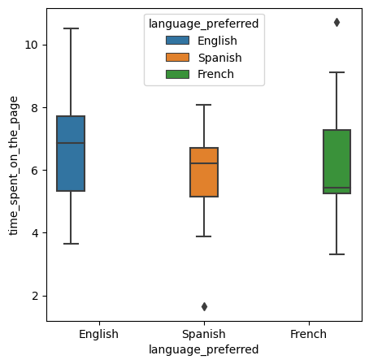

```python
# mean time spent on the new page at different preferred languages
print(df_new.groupby("language_preferred")["time_spent_on_the_page"].mean())

# create the boxplots
fig, ax = plt.subplots(figsize = (5,5))
a = sns.boxplot(x = "language_preferred", y = "time_spent_on_the_page", data = df_new, hue = "language_preferred")
```

- Check normality with Shapiro_Wilk's test applied to the response variable
- Check for equality of variance with the Levene test applied to the response variable

### Shapiro-Wilk's Test

> $H_0:$ Time spent on the new page follows a normal distribution against

> $H_a:$ Time spent on the new page does not follow a normal distribution

```python
# import the required function
from scipy import stats

# find the p-value
w, p_value = stats.shapiro(df_new['time_spent_on_the_page'])
print('The p-value is', str(round(p_value,5)))
```

```
The p-value is 0.804
```

#### Observations

- Since the p-value is much larger than 0.05, we fail to reject the null that time spent on the new page follows a normal distribution.

### Levene’s test

> $H_0$: All the population variances for time spent on the new page are equal

> $H_a$: At least one variance for time spent on the new page is different from the rest

```python
#import the required function
from scipy.stats import levene
statistic, p_value = levene( df_new['time_spent_on_the_page'][df_new['language_preferred']=="Spanish"],
                                   df_new['time_spent_on_the_page'][df_new['language_preferred']=="French"],
                                   df_new['time_spent_on_the_page'][df_new['language_preferred']=="English"])
# find the p-value
print('The p-value is', str(round(p_value,5)))
```

```
The p-value is 0.46711
```

#### Observations

- Since the p-value is much larger than 0.05, we fail to reject the null hypothesis of homogeneity among variances.

#### Are the assumptions satisified for a One-Way ANOVA F-Test?

- The populations are normally distributed - Yes, based on the Shapiro-Wilk's test.
- The samples are independent random samples - Yes, we are informed that this is true.
- Population variances are equal - Yes, based on Levene's test.

We can use a One-Way ANOVA F-Test to find the p-value to test the Null Hypothesis.

```python
#import the required function
from scipy.stats import f_oneway

# perform one-way anova test
test_stat, p_value = f_oneway(df_new.loc[df_new['language_preferred'] == 'Spanish', 'time_spent_on_the_page'],
                              df_new.loc[df_new['language_preferred'] == 'French', 'time_spent_on_the_page'],
                              df_new.loc[df_new['language_preferred'] == 'English', 'time_spent_on_the_page'])
print('The p-value is ' + str(round(p_value,5)))
```

```
The p-value is 0.43204
```

### Observations

The p-value is much larger at 0.43204 than the significance level of 0.05, therefore we do not have sufficient evidence to reject the null hypothesis that the time spent on the new page is the same for any of the preferred languages.

### Additional Analysis

```python
# create df_new where landing page is new
df_new = df[df['landing_page']=='new']
```

```python
# Find total converted for each language when landing page is new
df_new1 = df_new.drop(['user_id','group','landing_page','time_spent_on_the_page','converted'], axis=1)

df_new2 = df_new1.groupby(['language_preferred'])

df_new3 = df_new2.agg(sum_converted_yes = ('converted_yes', np.sum))

df_new4 = df_new2.agg(sum_converted_no = ('converted_no', np.sum))

df_new5 = pd.merge(df_new3,df_new4,how='left',on='language_preferred')

print(df_new5)
```

```
                    sum_converted_yes  sum_converted_no
language_preferred
English                            10                 6
French                             12                 5
Spanish                            11                 6
```

```python
#create df_old where landing page is old
df_old = df[df['landing_page']=='old']
```

```python
# Find total converted for each language when landing page is old
df_old1 = df_old.drop(['user_id','group','landing_page','time_spent_on_the_page','converted'], axis=1)

df_old2 = df_old1.groupby(['language_preferred'])

df_old3 = df_old2.agg(sum_converted_yes = ('converted_yes', np.sum))

df_old4 = df_old2.agg(sum_converted_no = ('converted_no', np.sum))

df_old5 = pd.merge(df_old3,df_old4,how='left',on='language_preferred')

print(df_old5)
```

```
                    sum_converted_yes  sum_converted_no
language_preferred
English                            11                 5
French                              3                14
Spanish                             7                10
```

## Conclusion and Business Recommendations

#### Conclusions

- Overall mean time spent on the landing page is 5.38 minutes.
  - Overall, first quartile, median, and third quartile are 3.88 minutes, 5.42 minutes, and 7.02 minutes, respectively for time spent on the landing page.
  - Mean time spent on the new landing page is 6.22 minutes, while the mean time spent on the old landing page is 4.53 minutes.
  - Statistical evidence supports that mean time spent on new landing page is greater than mean time spent on the old landing page.
- Overall, 54 users converted to subscribers out of 100.
  - 33 users out of 50 converted to subscribers with the new landing page, while 21 out of 50 converted to subscribers for the old landing page.
  - Statistical evidence supports that conversion rate for the new landing page is greater than the old landing page.
- Cannot reject the null that coversion to subscriber is independent of preferred languge.
  - For preferred language as English, 21 out of 32 converted to subscribers.
    - For the new landing page, 10 out of 16 converted.
  - For preferred language as French, 15 out of 34 converted to subscribers.
    - For the new landing page, 12 out of 17 converted.
  - For preferred language as Spanish, 18 out of 34 converted to subscribers.
    - For the new landing page, 11 out of 17 converted.
- Connot reject the null that time spent on the new page is the same for all three preferred languages.
  - For preferred language as English, the mean time spent on the new landing page is 6.66 minutes.
  - For preferred language as French, the mean time spent on the new landing page is 6.19 minutes.
  - For preferred language as Spanish, the mean time spent on the new landing page is 5.84 minutes.
- The median time spent on the landing page is around 4 minutes for users that were not converted to a subscriber while the median time spent on the landing page is around 6.5 minutes for users that were converted to a subscriber.